# HomeWork_1

Ekaterina Fokina

2022-10-18

# **Отчет для страховой компании**

Будем определять, какие факторы влияют на объем страховых выплат, то есть на затраты страховой компании.

## Загрузим наши данные (№1)

```r
insurance <- read.csv("insurance_cost.csv")
```

### *Взглянем на структуру данных*

```r
str(insurance)
```

```
## 'data.frame':    1338 obs. of  7 variables:
##  $ age     : int  19 18 28 33 32 31 46 37 37 60 ...
##  $ sex     : chr  "female" "male" "male" "male" ...
##  $ bmi     : num  27.9 33.8 33 22.7 28.9 ...
##  $ children: int  0 1 3 0 0 0 1 3 2 0 ...
##  $ smoker  : chr  "yes" "no" "no" "no" ...
##  $ region  : chr  "southwest" "southeast" "southeast" "northwest" ...
##  $ charges : num  16885 1726 4449 21984 3867 ...
```

### *И опишем датасет*

```r
summary(insurance)
```

```
##       age            sex                 bmi           children
##  Min.   :18.00   Length:1338        Min.   :15.96   Min.   :0.000
##  1st Qu.:27.00   Class :character   1st Qu.:26.30   1st Qu.:0.000
##  Median :39.00   Mode  :character   Median :30.40   Median :1.000
##  Mean   :39.21                      Mean   :30.66   Mean   :1.095
##  3rd Qu.:51.00                      3rd Qu.:34.69   3rd Qu.:2.000
##  Max.   :64.00                      Max.   :53.13   Max.   :5.000
##     smoker             region             charges
##  Length:1338        Length:1338        Min.   : 1122
##  Class :character   Class :character   1st Qu.: 4740
##  Mode  :character   Mode  :character   Median : 9382
##                                        Mean   :13270
##                                        3rd Qu.:16640
##                                        Max.   :63770
```

## Подгрузим необходимые пакеты

```r
library(dplyr)
library(ggplot2)
library(extrafont)
library(ggpubr)
```

## Гистограммы нумерических переменных (№2)

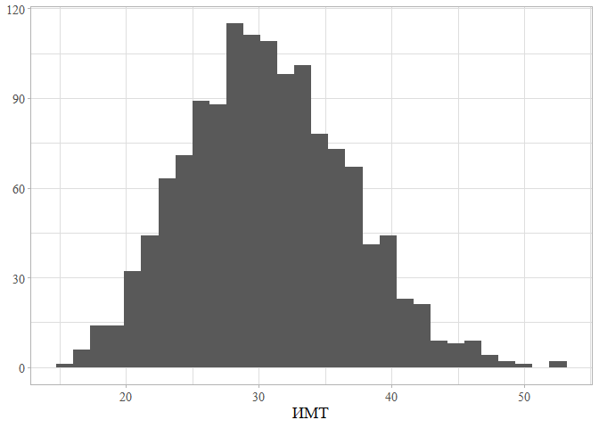

```r
ggplot() +
  geom_histogram(data = insurance,
                 aes(x = bmi)) +
  labs(x = "ИМТ") +
  theme_light() +
  theme(text = element_text(family = "serif", size = 14), axis.title.y = element_blank())
```

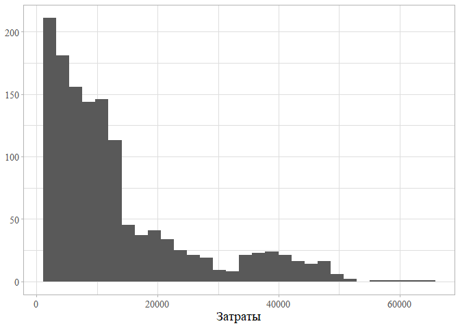

```r
ggplot() +
  geom_histogram(data = insurance,
                 aes(x = charges)) +
  labs(x = "Затраты") +
  theme_light() +
  theme(text = element_text(family = "serif", size = 14), axis.title.y = element_blank())
```

## График плотности для затрат (№3)

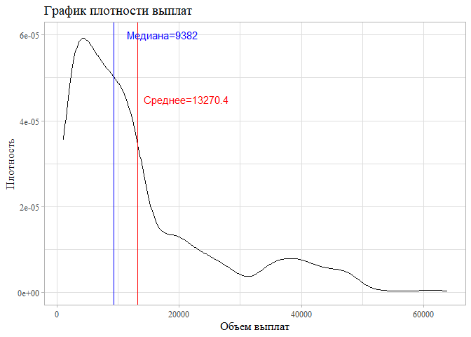

```r
# Найдем среднюю и медиану
charges_mean <- round(mean(insurance$charges), 1)
charges_median <- round(median(insurance$charges), 1)

density <- ggplot(data = insurance,
       aes(x = charges)) +
  geom_density() +
  geom_vline(aes(xintercept = charges_mean), color = "red") +
  annotate("text",
           x = charges_mean+8000,
           y = 4.5e-05,
           label=paste0("Среднее=", charges_mean), color = "red") +
  geom_vline(aes(xintercept = charges_median), color = "blue") +
  annotate("text",
           x= charges_median + 8000,
           y = 6e-05,
           label = paste0("Медиана=", charges_median), color = "blue") +
    ggtitle("График плотности выплат") +
  labs(x = "Объем выплат", y = "Плотность") +
  theme_light() +
  theme(text = element_text(family = "serif", size = 12))

density
```

## Соотношение переменных (№4)

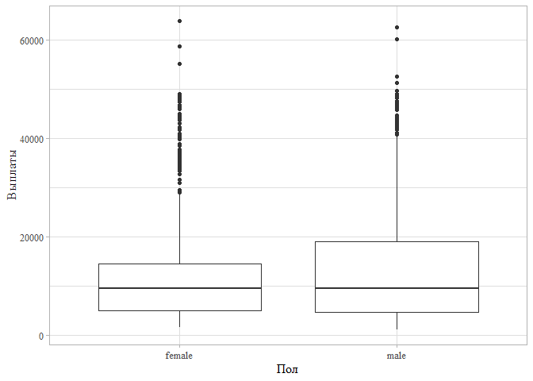

```r
boxplot_sex <- ggplot() +
  geom_boxplot(data = insurance,
                 aes(x = charges, y = sex)) +
  labs(x = "Выплаты", y = "Пол") +
  theme_light() +
  coord_flip() +
  theme(text = element_text(family = "serif", size = 12))

boxplot_sex
```

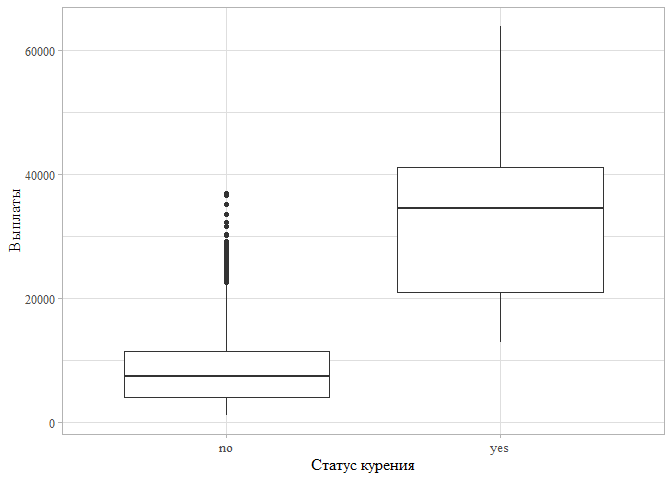

```r
boxplot_smoker <- ggplot() +
  geom_boxplot(data = insurance,
                 aes(x = charges, y = smoker)) +
  labs(x = "Выплаты", y = "Статус курения") +
  theme_light() +
  coord_flip() +
  theme(text = element_text(family = "serif", size = 12))

boxplot_smoker
```

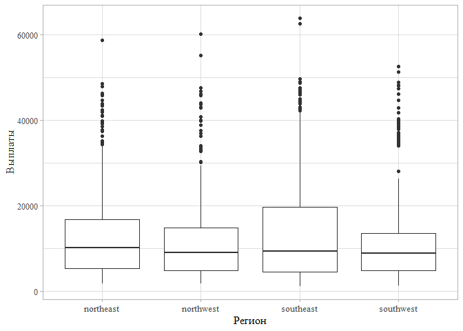

```r
boxplot_region <-ggplot() +
  geom_boxplot(data = insurance,
                 aes(x = charges, y = region)) +
  labs(x = "Выплаты", y = "Регион") +
  theme_light() +
  coord_flip() +
  theme(text = element_text(family = "serif", size = 12))

boxplot_region
```

## Объединяем графики (№5)

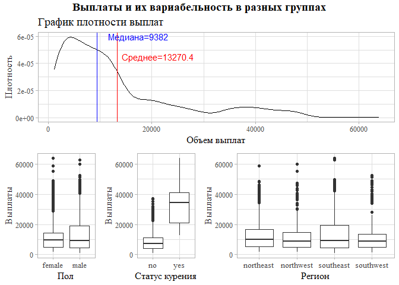

```r
# Объединим наши боксплоты
boxplots_together <- ggarrange(boxplot_sex, boxplot_smoker, boxplot_region, ncol = 3, nrow = 1, widths = c(1, 1, 2))

# И добавим к ним график плотности
big_plot <- ggarrange(density, boxplots_together, ncol = 1, nrow = 2)

annotate_figure(big_plot, top = text_grob("Выплаты и их вариабельность в разных группах", size = 14, face = "bold", family = "serif"))
```

## Делаем фасет по регионам (№6)

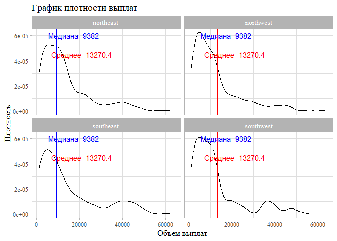

```r
density + facet_wrap(vars(region))
```

```r
# Использовала facet_wrap, потому что _grid расставляет все четыре графика в ряд, и они выглядят несуразно суженными
# Пыталась найти способ отрегулировать высоту колонок или расположение графиков в _grid, но решение не нашлось...
```

## Зависимость страховых выплат от возраста (№7)

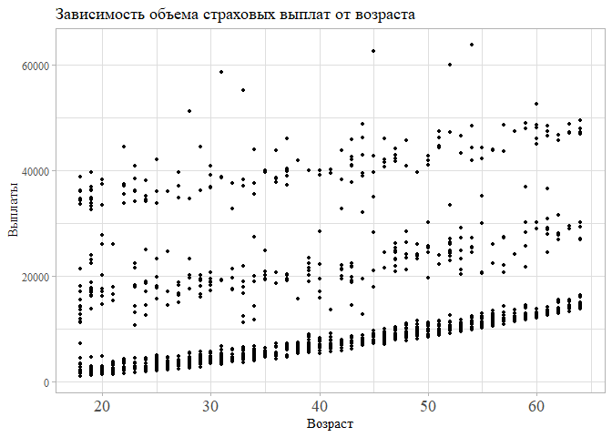

```r
scatter <- ggplot() +
  geom_point(data = insurance,
             aes(x = age, y = charges), size = 1) +
  ggtitle("Зависимость объема страховых выплат от возраста") +
  labs(x = "Возраст", y = "Выплаты") +
  theme_light()

scatter + theme(text = element_text(family = "serif"),
  axis.text.x = element_text(size = 14))
```

### Построим линию тренда для предыдущего графика (№8)

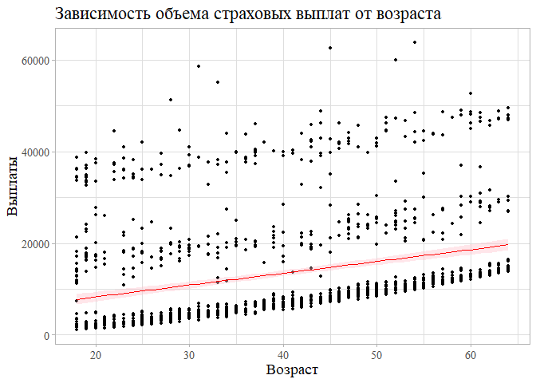

```r
insurance %>%
  ggplot(aes(x = age, y = charges)) +
  geom_point(size = 1) +
  geom_smooth(method = lm,
              color = "red", fullrange = T,
              fill = "pink",
              se = TRUE,
              size = 0.2) +
  ggtitle("Зависимость объема страховых выплат от возраста") +
  labs(x = "Возраст", y = "Выплаты") +
  theme_light() +
  theme(text = element_text(family = "serif", size = 14))
```

### А влияет ли курение на эту зависимость? (№9)

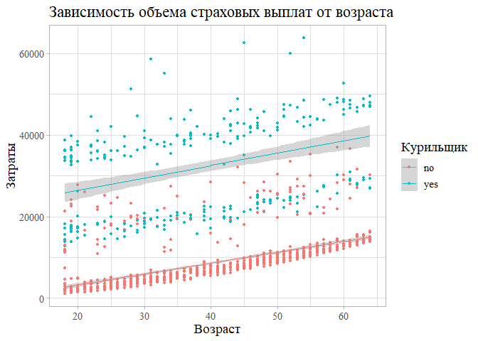

```r
insurance %>%
  ggplot(aes(x = age, y = charges, color = smoker, group = smoker)) +
  geom_point(size = 1) +
  geom_smooth(method = lm,
              se = TRUE,
              size = 0.2) +
  ggtitle("Зависимость объема страховых выплат от возраста") +
  labs(x = "Возраст", y = "Затраты") +
  guides(color = guide_legend(title = "Курильщик")) +
  theme_light() +
  theme(text = element_text(family = "serif", size = 14))
```

## Зависимость страховых выплат от ИМТ (№10)

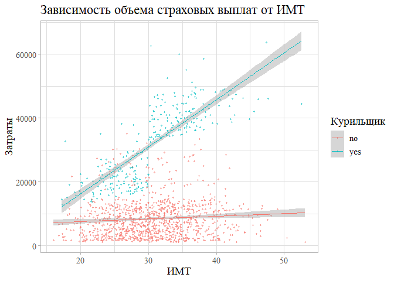

```r
insurance %>%
  ggplot(aes(x = bmi, y = charges, color = smoker, group = smoker)) +
  geom_point(size = 0.75, alpha = 0.5) +
  geom_smooth(method = lm,
              se = TRUE,
              size = 0.2) +
  ggtitle("Зависимость объема страховых выплат от ИМТ") +
  labs(x = "ИМТ", y = "Затраты") +
  guides(color = guide_legend(title = "Курильщик")) +
  theme_light() +
  theme(text = element_text(family = "serif", size = 14))
```

## **Зададим вопросы!**

### Вопрос к данным №1 (№11)

*Различается ли ИМТ женищин в зависимости от региона проживания?*

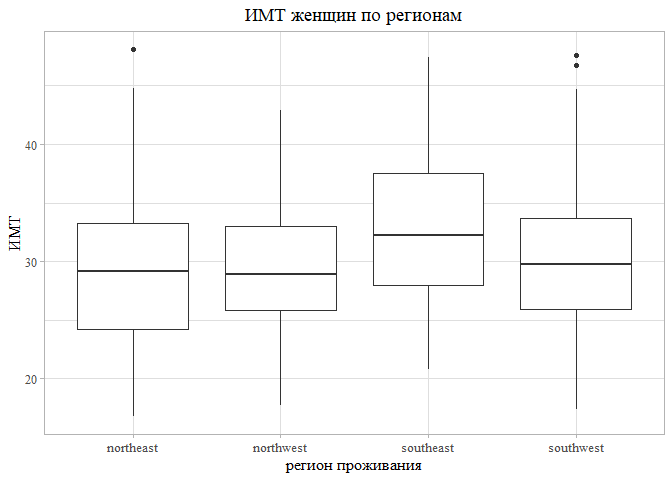

```r
insurance %>%
  filter(sex == "female") %>%
  ggplot(aes(x = bmi, y = region)) +
  geom_boxplot() +
  labs(y = "регион проживания", x = "ИМТ") +
  ggtitle("ИМТ женщин по регионам") +
  theme_light() +
  coord_flip() +
  theme(text = element_text(family = "serif", size = 12), plot.title = element_text(hjust = 0.5, size = 14))
```

### Вопрос к данным №2 (№12)

*Меняется ли объем страховых выплат жителям региона northwest с возрастом в зависимости от наличия хотя бы одного ребенка?*

Для этого построим график типа scatterplot, так как возраст и выплаты - числовые переменные. Затем на графике построим линии тренда, сгруппировав людей в зависимости от наличия или отсуствия детей.

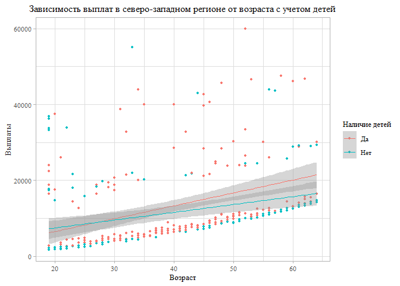

```r
insurance <- insurance %>%
  mutate(any_child = as.character(ifelse(children >= 1, "Да", "Нет")))

insurance %>%
  filter(region == "northwest") %>%
  ggplot(aes(x = age, y = charges, color = any_child, group = any_child)) +
  geom_point(size = 1) +
  geom_smooth(method = lm,
              se = TRUE,
              size = 0.2) +
  ggtitle("Зависимость выплат в северо-западном регионе от возраста с учетом детей") +
  labs(x = "Возраст", y= "Выплаты") +
  guides(color = guide_legend(title = "Наличие детей")) +
  theme_light() +
  theme(text = element_text(family = "serif", size = 10), plot.title = element_text(hjust = 0.5, size = 12))
```

Как видно из представленного графика, объем страховых выплат имеет тенденцию повышаться с возрастом у лиц, которые обзавелись хотя бы одним ребенком, хотя различия статистически не значимы.

### Вопрос к данным №3 (№13)

*Зависит ли объем страховых выплат женщинам от количества детей в семье?*

Для ответа на вопрос построим столбчатую диаграмму, где по оси *x* будет количество детей, а по оси *y* - среднее значение страховых выплат среди женщин.

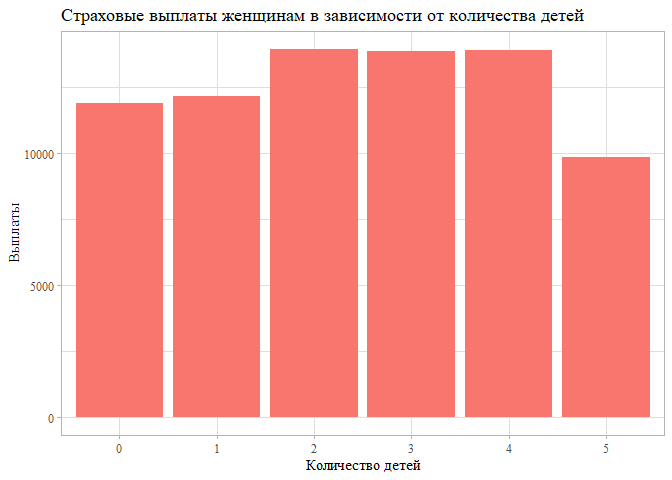

```r
mean_charges_0 <- round(mean(insurance$charges[insurance$sex == "female" & insurance$children == 0]),1)

mean_charges_1 <- round(mean(insurance$charges[insurance$sex == "female" & insurance$children == 1]),1)

mean_charges_2 <- round(mean(insurance$charges[insurance$sex == "female" & insurance$children == 2]),1)

mean_charges_3 <- round(mean(insurance$charges[insurance$sex == "female" & insurance$children == 3]),1)

mean_charges_4 <- round(mean(insurance$charges[insurance$sex == "female" & insurance$children == 4]),1)

mean_charges_5 <- round(mean(insurance$charges[insurance$sex == "female" & insurance$children == 5]),1)

mean_charges <- c(mean_charges_0, mean_charges_1, mean_charges_2, mean_charges_3, mean_charges_4, mean_charges_5)

children <- c(0, 1, 2, 3, 4, 5)

my_df <- data.frame(mean_charges, children)
my_df$children <- as.factor(my_df$children)

ggplot() +
  geom_col(data = my_df, aes(x = children, y = mean_charges, fill = "pink")) +
  ggtitle("Страховые выплаты женщинам в зависимости от количества детей") +
  labs(x = "Количество детей", y = "Выплаты") +
  theme_light() +
  theme(legend.position = "none", text = element_text(family = "serif"))
```

Из графика следует, что скорее всего значимых отличий в уровне страховых выплат женщинам в зависимости от количества детей, нет. Однако для более точного анализа необходимо дополнить график доверительными интервалами.

## Воспроизведем график (№14)

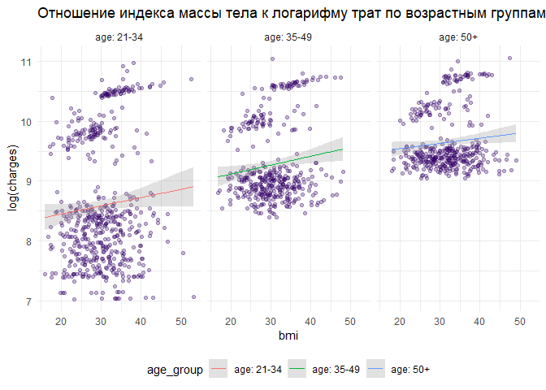

```r
insurance <- insurance %>%
  mutate(
      age_group = case_when(
      age < 35 ~ "age: 21-34",
      age >= 35 & age < 50 ~ "age: 35-49",
      age >= 50 ~ "age: 50+"
    ))

insurance %>%
  ggplot(aes(x = bmi, y = log(charges), group = age_group, color = age_group)) +
  geom_point(color = "#330066", alpha = 0.3) +
  facet_grid(.~ age_group) +
  geom_smooth(method=lm,
              alpha = 0.3,
              se=TRUE,
              size = 0.7,
              group = "age_group"
  ) +
  ggtitle("Отношение индекса массы тела к логарифму трат по возрастным группам") +
  theme_minimal() +
  theme(legend.position = "bottom")
```